# Week 4 Exercises

# Exercise 1

Read the region_scores.csv data (make sure you have the data file in the right folder).

Create a figure that shows the distributions (density plots or histograms) of **age** and **score** in separate subplots (facets). What do you need to do first?

In the figure, set individual x-axis limits for age and score by modifying the `scales` parameter within `facet_wrap()`.

**Hint**: To make things simpler, you can begin by selecting only the variables you need here, i.e. age and score.

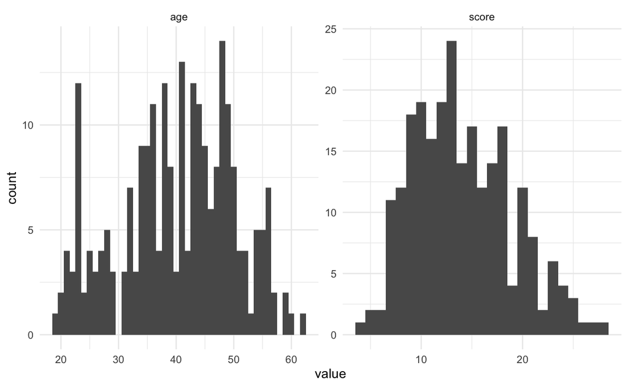

```r
df %>% gather(key = "key", value = value, 5:6) %>% ggplot(aes(x=value)) +
  geom_histogram(binwidth = 1) +
  facet_wrap("key", scales = "free") +
  theme_minimal()
```

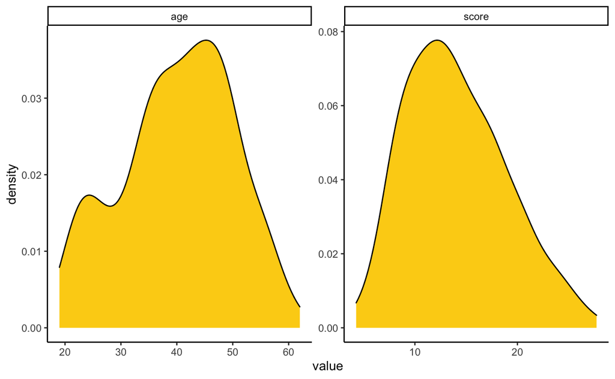

```r
df %>% gather(key = "key", value = value, 5:6) %>% ggplot(aes(x=value)) +
  geom_density(fill="#fcd116") +
  facet_wrap("key", scales = "free") +
  theme_classic()
```

# Exercise 2

In this exercise, you will use the built-in iris dataset.

```r
head(iris)
```

|  | Sepal.Length | Sepal.Width | Petal.Length | Petal.Width | Species |
| --- | --- | --- | --- | --- | --- |
| 1 | 5.1 | 3.5 | 1.4 | 0.2 | setosa |
| 2 | 4.9 | 3.0 | 1.4 | 0.2 | setosa |
| 3 | 4.7 | 3.2 | 1.3 | 0.2 | setosa |
| 4 | 4.6 | 3.1 | 1.5 | 0.2 | setosa |
| 5 | 5.0 | 3.6 | 1.4 | 0.2 | setosa |
| 6 | 5.4 | 3.9 | 1.7 | 0.4 | setosa |

#### 2.1

Make the data into long format: gather all variables except species into new variables **var** (variable names) and **measure** (numerical values). You should end up with 600 rows and 3 columns (Species, var, and measure). Assign the result into `iris_long`.

```r
iris_long <- iris %>% gather(key = "var", value = measure, -Species)
```

#### 2.2

In `iris_long`, separate **var** into two variables: **part** (Sepal/Petal values) and **dim** (Length/Width).

Then, spread the measurement values to new columns that get their names from **dim**. You must create row numbers by dim group before doing this.

You should now have 300 rows of variables Species, part, Length and Width (and row numbers). Assign the result into `iris_wide`.

```r
iris_wide <- iris_long %>% separate(var, c("part", "dim")) %>% group_by(dim) %>% mutate(row_no = row_number()) %>% spread(dim, measure)
```

#### 2.3

Using `iris_wide`, plot a scatter plot of length on the x-axis and width on the y-axis. Colour the points by part.

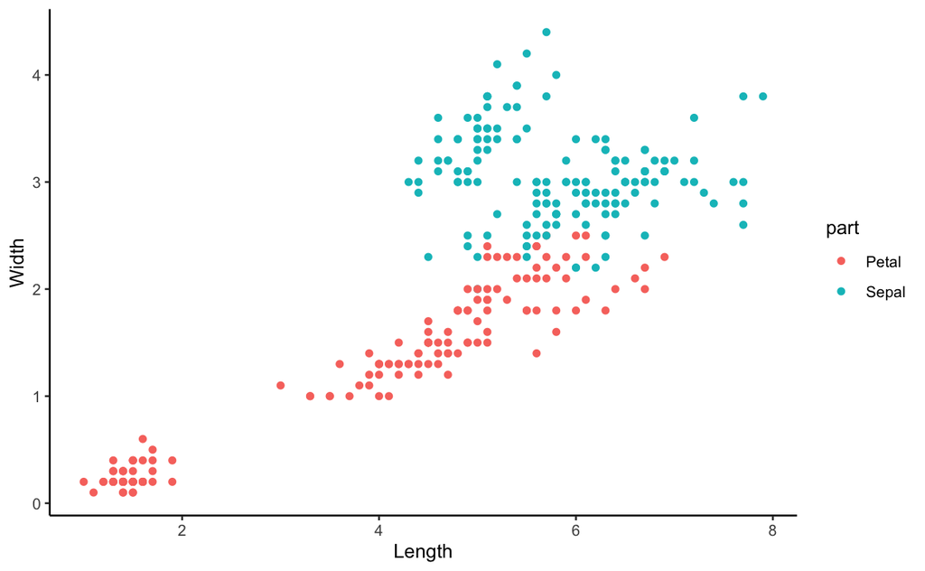

```r
iris_wide %>% ggplot(aes(x = Length, y = Width, color = part)) +
  geom_point() +
  theme_classic()
```

# Working with your own data

In exercises 3-5, you’ll work with your own dataset. **If you don’t have you own data, use the fss_learning.csv data (see description below).**

In these exercises, you are required to provide an overview of your data, using the tools we have learned so far. Because all datasets are different, the format of the exercises is quite open. You will get points for being thorough and trying your best - even if you didn’t know how to write something in code, be explicit with what you were **trying** to achieve. When submitting the exercises, **please return both an .Rmd and an .html file! The HTML file created by previewing a Notebook (with the suffix .nb.html) is fine, but make sure that the HTML contains all the code and output that is needed for getting an impression of the data. In other words, the document needs to be readable without having access to the full dataset.**

#### the fss_learning data

fss_learning.csv contains data from a longitudinal skill learning experiment. There are observations at multiple levels: a total of 18 **participants**, each completing 8 **sessions** which consist of 5 **runs** (trials) of a game-like driving task (i.e. 8*5 = 40 trials per participant). You can read more about the design [here](https://doi.org/10.3389/fpsyg.2019.01126).

In the data, there are trial-level measures related to performance (number of **collisions**, **duration** in seconds, **distance** travelled), as well as self-reports on a scale of 1-7 (variables fluency:comp3) collected after each trial or session.

# Exercise 3

As I don’t have suitable data for these exercises I’ll do the ex 3 and ex 4 with the fss_learning data. Additionally, in ex 5 I describe my network data I have now and will have in the future. I also make some network visualizations with example data.

#### 3.1

Importing fss data into R.

#### 3.2

Print the structure/glimpse/summary of the data. Outline briefly what kind of variables you have and if there are any missing or abnormal values. Make sure that each variable has the right class (numeric/character/factor etc).

```r
structure(fss)
```

| participant | gender | session | run | collisions | duration | distance | cumrun | fluency | absorption | flow | pi1 | pi2 | pi3 | comp1 | comp2 | comp3 |
| --- | --- | --- | --- | --- | --- | --- | --- | --- | --- | --- | --- | --- | --- | --- | --- | --- |
| 1 | male | 1 | 1 | 26 | 233.6105 | 24196.57 | 1 | 4.75 | 6.0 | 5.444444 | 5 | 2 | 3 | NA | NA | NA |
| 1 | male | 1 | 2 | 30 | 204.8506 | 24197.47 | 2 | 4.50 | 4.6 | 4.555556 | 3 | 2 | 2 | NA | NA | NA |
| 1 | male | 1 | 3 | 20 | 190.1887 | 24199.04 | 3 | 5.25 | 5.4 | 5.333333 | 5 | 3 | 2 | NA | NA | NA |
| 1 | male | 1 | 4 | 13 | 181.4123 | 24197.93 | 4 | 5.00 | 5.0 | 5.000000 | 4 | 3 | 2 | NA | NA | NA |
| 1 | male | 1 | 5 | 18 | 188.9267 | 24197.89 | 5 | 4.25 | 4.6 | 4.444444 | 4 | 3 | 2 | 3 | 5 | 4 |
| 1 | male | 2 | 1 | 18 | 184.5798 | 24197.58 | 6 | 4.00 | 4.8 | 4.444444 | 3 | 3 | 3 | NA | NA | NA |
| 1 | male | 2 | 2 | 21 | 173.1695 | 24196.49 | 7 | 5.50 | 5.6 | 5.555556 | 4 | 4 | 3 | NA | NA | NA |
| 1 | male | 2 | 3 | 20 | 187.3442 | 24196.84 | 8 | 4.00 | 5.0 | 4.555556 | 4 | 3 | 3 | NA | NA | NA |
| 1 | male | 2 | 4 | 15 | 173.9570 | 24197.68 | 9 | 5.00 | 5.8 | 5.444444 | 5 | 3 | 2 | NA | NA | NA |
| 1 | male | 2 | 5 | 15 | 197.1904 | 24198.82 | 10 | 3.75 | 4.2 | 4.000000 | 3 | 3 | 3 | 3 | 5 | 4 |

[output cut: 710 more lines]

```r
glimpse(fss)
```

```
Rows: 720
Columns: 17
$ participant <dbl> 1, 1, 1, 1, 1, 1, 1, 1, 1, 1, 1, 1, 1, 1, 1, 1, 1, 1, 1, 1, 1, 1, 1, 1, 1, 1, 1, 1, 1, 1, 1, 1, 1, 1,…
$ gender      <chr> "male", "male", "male", "male", "male", "male", "male", "male", "male", "male", "male", "male", "male…
$ session     <dbl> 1, 1, 1, 1, 1, 2, 2, 2, 2, 2, 3, 3, 3, 3, 3, 4, 4, 4, 4, 4, 5, 5, 5, 5, 5, 6, 6, 6, 6, 6, 7, 7, 7, 7,…
$ run         <dbl> 1, 2, 3, 4, 5, 1, 2, 3, 4, 5, 1, 2, 3, 4, 5, 1, 2, 3, 4, 5, 1, 2, 3, 4, 5, 1, 2, 3, 4, 5, 1, 2, 3, 4,…
$ collisions  <dbl> 26, 30, 20, 13, 18, 18, 21, 20, 15, 15, 21, 17, 8, 18, 13, 15, 12, 15, 12, 17, 14, 12, 11, 15, 8, 10,…
$ duration    <dbl> 233.6105, 204.8506, 190.1887, 181.4123, 188.9267, 184.5798, 173.1695, 187.3442, 173.9570, 197.1904, 1…
$ distance    <dbl> 24196.57, 24197.47, 24199.04, 24197.93, 24197.89, 24197.58, 24196.49, 24196.84, 24197.68, 24198.82, 2…
$ cumrun      <dbl> 1, 2, 3, 4, 5, 6, 7, 8, 9, 10, 11, 12, 13, 14, 15, 16, 17, 18, 19, 20, 21, 22, 23, 24, 25, 26, 27, 28…
$ fluency     <dbl> 4.75, 4.50, 5.25, 5.00, 4.25, 4.00, 5.50, 4.00, 5.00, 3.75, 4.75, 4.25, 6.25, 4.50, 5.00, 5.00, 4.50,…
$ absorption  <dbl> 6.0, 4.6, 5.4, 5.0, 4.6, 4.8, 5.6, 5.0, 5.8, 4.2, 4.6, 5.2, 5.6, 5.6, 5.0, 5.0, 4.2, 5.0, 5.4, 4.6, 4…
$ flow        <dbl> 5.444444, 4.555556, 5.333333, 5.000000, 4.444444, 4.444444, 5.555556, 4.555556, 5.444444, 4.000000, 4…
$ pi1         <dbl> 5, 3, 5, 4, 4, 3, 4, 4, 5, 3, 4, 4, 5, 4, 3, 4, 4, 4, 5, 4, 5, 5, 4, 4, 4, 4, 5, 4, 4, 5, 4, 4, 3, 3,…
$ pi2         <dbl> 2, 2, 3, 3, 3, 3, 4, 3, 3, 3, 3, 4, 4, 3, 4, 3, 3, 4, 5, 4, 4, 4, 3, 3, 4, 4, 4, 4, 4, 4, 3, 3, 3, 3,…
$ pi3         <dbl> 3, 2, 2, 2, 2, 3, 3, 3, 2, 3, 3, 4, 3, 3, 3, 3, 4, 4, 4, 3, 4, 4, 3, 3, 3, 2, 2, 2, 2, 2, 3, 2, 2, 2,…
$ comp1       <dbl> NA, NA, NA, NA, 3, NA, NA, NA, NA, 3, NA, NA, NA, NA, 3, NA, NA, NA, NA, 3, NA, NA, NA, NA, 3, NA, NA…
$ comp2       <dbl> NA, NA, NA, NA, 5, NA, NA, NA, NA, 5, NA, NA, NA, NA, 5, NA, NA, NA, NA, 5, NA, NA, NA, NA, 5, NA, NA…
$ comp3       <dbl> NA, NA, NA, NA, 4, NA, NA, NA, NA, 4, NA, NA, NA, NA, 4, NA, NA, NA, NA, 4, NA, NA, NA, NA, 4, NA, NA…
```

```r
summary(fss)
```

```
  participant      gender             session          run      collisions       duration        distance
 Min.   : 1.0   Length:720         Min.   :1.00   Min.   :1   Min.   : 4.00   Min.   :160.0   Min.   :24196
 1st Qu.: 5.0   Class :character   1st Qu.:2.75   1st Qu.:2   1st Qu.:13.00   1st Qu.:172.5   1st Qu.:24197
 Median : 9.5   Mode  :character   Median :4.50   Median :3   Median :17.00   Median :181.3   Median :24198
 Mean   : 9.5                      Mean   :4.50   Mean   :3   Mean   :17.67   Mean   :186.3   Mean   :24198
 3rd Qu.:14.0                      3rd Qu.:6.25   3rd Qu.:4   3rd Qu.:22.00   3rd Qu.:194.7   3rd Qu.:24198
 Max.   :18.0                      Max.   :8.00   Max.   :5   Max.   :43.00   Max.   :413.3   Max.   :24200
                                                              NA's   :1       NA's   :1       NA's   :1
     cumrun         fluency        absorption         flow            pi1             pi2             pi3
 Min.   : 1.00   Min.   :2.000   Min.   :2.400   Min.   :2.444   Min.   :1.000   Min.   :1.000   Min.   :1.000
 1st Qu.:10.50   1st Qu.:4.000   1st Qu.:4.700   1st Qu.:4.444   1st Qu.:5.000   1st Qu.:2.000   1st Qu.:1.000
 Median :20.00   Median :4.750   Median :5.200   Median :5.000   Median :6.000   Median :4.000   Median :2.000
 Mean   :20.47   Mean   :4.617   Mean   :5.248   Mean   :4.968   Mean   :5.328   Mean   :3.702   Mean   :2.713
 3rd Qu.:30.00   3rd Qu.:5.250   3rd Qu.:5.800   3rd Qu.:5.556   3rd Qu.:6.000   3rd Qu.:5.000   3rd Qu.:4.000
 Max.   :40.00   Max.   :7.000   Max.   :7.000   Max.   :7.000   Max.   :7.000   Max.   :7.000   Max.   :7.000
 NA's   :1       NA's   :1       NA's   :1       NA's   :1       NA's   :1       NA's   :1       NA's   :1
     comp1           comp2           comp3
 Min.   :1.000   Min.   :2.000   Min.   :2.000
 1st Qu.:3.000   1st Qu.:4.000   1st Qu.:4.000
 Median :3.000   Median :4.000   Median :4.000
 Mean   :3.514   Mean   :4.264   Mean   :3.993
 3rd Qu.:5.000   3rd Qu.:5.000   3rd Qu.:4.000
 Max.   :6.000   Max.   :6.000   Max.   :6.000
 NA's   :576     NA's   :576     NA's   :576
```

```r
fss <- fss %>% mutate(gender = as.factor(gender),
                      participant = as.integer(participant),
                      session = as.integer(session),
                      run = as.integer(run),
                      cumrun = as.integer(cumrun))

head(fss)
```

| participant | gender | session | run | collisions | duration | distance | cumrun | fluency | absorption | flow | pi1 | pi2 | pi3 | comp1 | comp2 | comp3 |
| --- | --- | --- | --- | --- | --- | --- | --- | --- | --- | --- | --- | --- | --- | --- | --- | --- |
| 1 | male | 1 | 1 | 26 | 233.6105 | 24196.57 | 1 | 4.75 | 6.0 | 5.444444 | 5 | 2 | 3 | NA | NA | NA |
| 1 | male | 1 | 2 | 30 | 204.8506 | 24197.47 | 2 | 4.50 | 4.6 | 4.555556 | 3 | 2 | 2 | NA | NA | NA |
| 1 | male | 1 | 3 | 20 | 190.1887 | 24199.04 | 3 | 5.25 | 5.4 | 5.333333 | 5 | 3 | 2 | NA | NA | NA |
| 1 | male | 1 | 4 | 13 | 181.4123 | 24197.93 | 4 | 5.00 | 5.0 | 5.000000 | 4 | 3 | 2 | NA | NA | NA |
| 1 | male | 1 | 5 | 18 | 188.9267 | 24197.89 | 5 | 4.25 | 4.6 | 4.444444 | 4 | 3 | 2 | 3 | 5 | 4 |
| 1 | male | 2 | 1 | 18 | 184.5798 | 24197.58 | 6 | 4.00 | 4.8 | 4.444444 | 3 | 3 | 3 | NA | NA | NA |

# Exercise 4

Pick a few (2-5) variables of interest from your data (ideally, both categorical and numerical).

For **categorical variables**, count the observations in each category (or combination of categories). Are the frequencies balanced?

Only categorical variable variable count that I’m intrested is gender.

```r
fss %>% count(gender)
```

| gender | n |
| --- | --- |
| female | 320 |
| male | 400 |

I this this is ok, even if it is not quite equal.

For **numerical variables**, compute some summary statistics (e.g. min, max, mean, median, SD) over the whole dataset or for subgroups. What can you say about the distributions of these variables, or possible group-wise differences?

```r
fss_means <- fss %>% group_by(participant, session) %>% summarise(flow_mean = mean(flow, na.rm = TRUE), flow_sd = sd(flow, na.rm = TRUE), collisions_mean = mean(collisions, na.rm = TRUE), speed = mean(distance/duration)) # participant 8 has some NA values, using na.rm = TRUE functions no to drop those NA values before computung the summary statistic. Otherwise the result would also be just NA
head(fss_means)
```

| participant | session | flow_mean | flow_sd | collisions_mean | speed |
| --- | --- | --- | --- | --- | --- |
| 1 | 1 | 4.955556 | 0.4485918 | 21.4 | 122.0807 |
| 1 | 2 | 4.800000 | 0.6731169 | 17.8 | 132.3599 |
| 1 | 3 | 5.088889 | 0.4804833 | 15.4 | 136.3529 |
| 1 | 4 | 4.844444 | 0.4346135 | 14.2 | 138.7427 |
| 1 | 5 | 5.222222 | 0.7157833 | 12.0 | 139.7169 |
| 1 | 6 | 5.666667 | 0.2832789 | 8.4 | 147.7176 |

Let’s try to make a bubble plot.

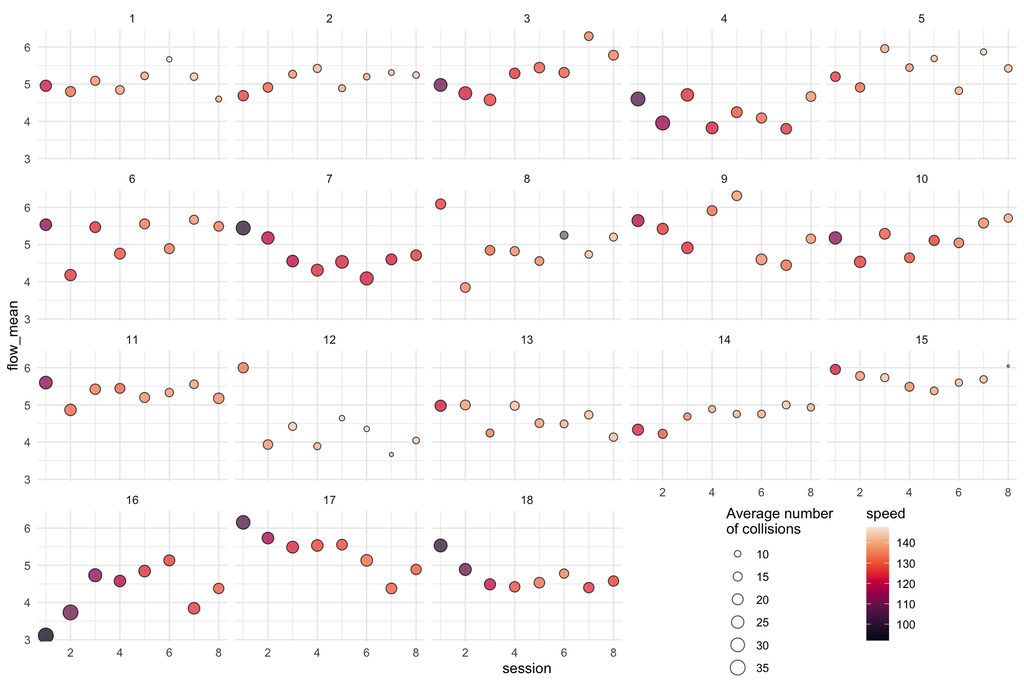

```r
fss_means %>% ggplot(aes(x = session, y = flow_mean, size = collisions_mean, fill = speed)) +
  geom_point(alpha = 0.75, shape=21, color = "black") +
  scale_size(range = c(0.5, 5), name="Average number \nof collisions") +
  scale_fill_viridis(option="F") +
  facet_wrap("participant") +
  theme_minimal() +
  theme(legend.position = c(0.8, 0.08), legend.box = 'horizontal')
```

Even tough it is possible to include lot of information into a bubble plot, I don’t think it is that useful or good. At least not here with the 18 facets. In some limited cases it might be applicable with a single facet if all the variables are meaningfully connected.

# Exercise 5

The network data I have is used in article I have submitted, but I do not want make the data set public just yet (everything I do in this course is on my GitHub on a public repository). But I describe the data and use social network data from a movie for learning igraph package and network visualizations.

#### 5.1

Describe if there’s anything else you think should be done as “pre-processing” steps (e.g. recoding/grouping values, renaming variables, removing variables or mutating new ones, reshaping the data to long format, merging data frames together).

The network data I have in my own research is already in nice format. Actually, for the next analyses I will still use Python as I have the network data as graph-tool objects and I have all useful functions already written. However, if need be the network data is easily tranferred as link-list in dataframes between python and R.

In another project I might need to analyze concept maps as networks. I get the concept map data as json-files and I need to write simple function to convert the data into a igraph object. This should be straightforward with the jsonlite library.

#### 5.2

Do you have an idea of what kind of relationships in your data you would like to visualise and for which variables? For example, would you like to depict variable distributions, the structure of multilevel data, summary statistics (e.g. means), or include model fits or predictions?

Depending which network I’m analyzing I need to compute different centrality measures. Those measures are then used in the network visualizations. In my own research I need to compute correlations between different network measures and also, maybe, centrality distributions. With the **ggpairs** these are visualized nicely.

# Network Visualizations with igraph

This is my own exercise to learn igraph package and to visualize (and analyze) networks.

I selected one of my favorite movies, *Big Lebowski* to experiment with. First, load the data as network and print all nodes.

```r
g <- movie_103 # network g of the Big Lebowski
V(g) # all nodes
```

```
+ 37/37 vertices, named, from fb41dcd:
 [1] ALLAN        BARTENDER    BLOND MAN    BRANDT       BUNNY        CHIEF        CHINESE MAN  DA FINO      DIETER
[10] DONNELLY     DONNY        DRIVER       DUDE         FIRST MAN    FRANZ        GARY         HALLWAY      KIEFFER
[19] MAN          MAUDE        OLDER COP    PILAR        POLICEMAN    QUINTANA     SECOND MAN   SMOKEY       THE STRANGER
[28] THIRD MAN    TONY         TREEHORN     WAITRESS     WALTER       WOMAN        WOO          YOUNG MAN    YOUNG WOMAN
[37] YOUNGER COP
```

Let’s make two simple plots with different layouts and settings

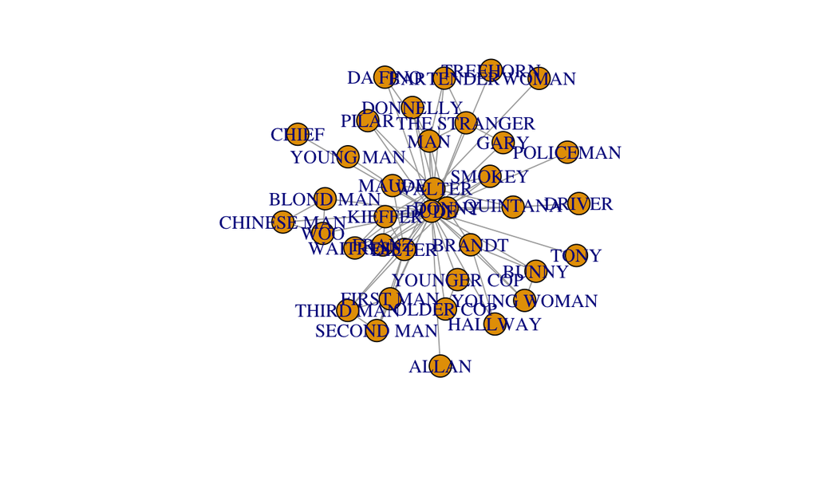

```r
plot(g
     )
```

Let’s make it bigger with circular layout and nocer colors.

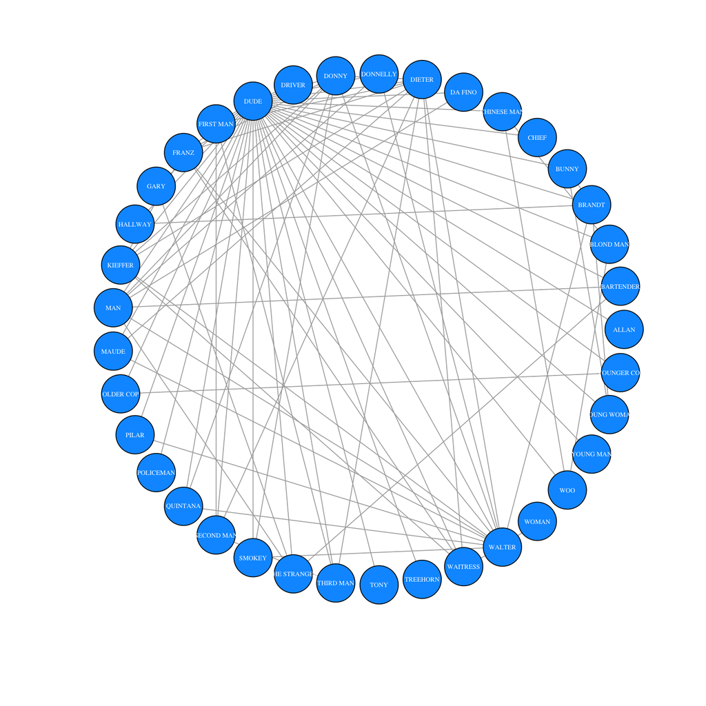

```r
plot(g,
     layout = layout.circle(g),
     vertex.size=15,
    vertex.color="#009bff",
    vertex.label.cex=0.5,
    vertex.label.color="white",
    vertex.frame.color="black")
```

Let’s now calculate network measures and use those for nicer plots.

```r
# degree_centrality
df <- base::as.data.frame(degree(g))
colnames(df) <- c("deg")
# eigen_centrality
df$eig <- eigen_centrality(g)$vector
# page_rank
df$pr <-  page_rank(g)$vector
# Katz_degree
# There's no function to calculate katz-centrality. Need to make my own, if I plan to use R for my analyses.
df <- df %>% mutate(deg = as.integer(deg))
head(df)
```

|  | deg | eig | pr |
| --- | --- | --- | --- |
| ALLAN | 1 | 0.02940050 | 0.00659938 |
| BARTENDER | 3 | 0.03617716 | 0.01260112 |
| BLOND MAN | 3 | 0.06158241 | 0.01651148 |
| BRANDT | 5 | 0.32386711 | 0.04300233 |
| BUNNY | 3 | 0.04010136 | 0.01285149 |
| CHIEF | 1 | 0.02940050 | 0.00659938 |

Also ggpairs-plot for the measures. All correlate nicely, as they should!

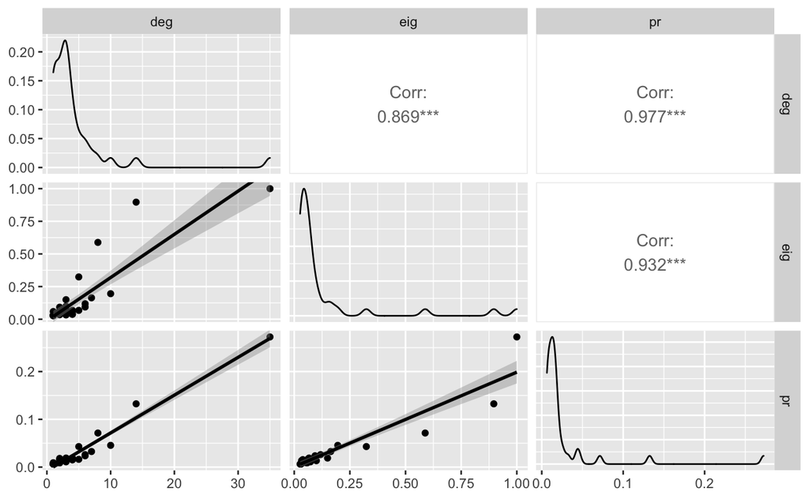

```r
df %>% ggpairs(lower = list(continuous = "smooth"))
```

Plot with *Kamada & Kawai* layout and node size from node degree.

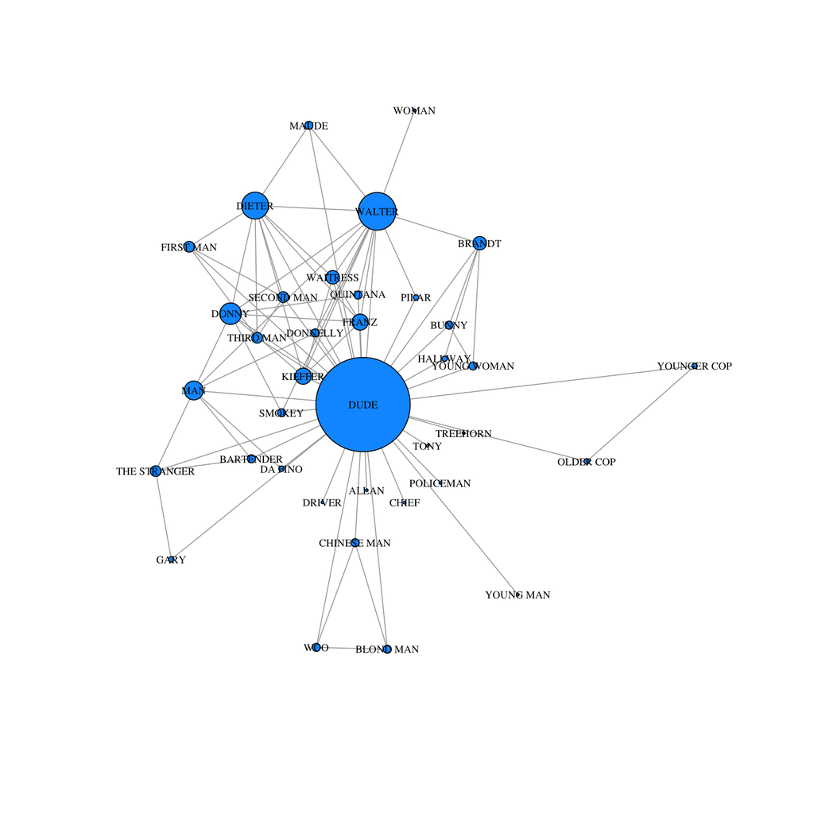

```r
plot(g,
     layout = layout.kamada.kawai(g),
     vertex.size=df$deg,
     vertex.color="#009bff",
     vertex.label.cex=0.7,
     vertex.label.color="black",
     vertex.frame.color="black")
```

Star plot with the *Dude* rightfully in the center and using eigencentrality to set the order and size of the nodes. It would be nicer to be able to set the starting point for the circular layout so that *Walter* would on top. I did not find a simple or easy way to do this.

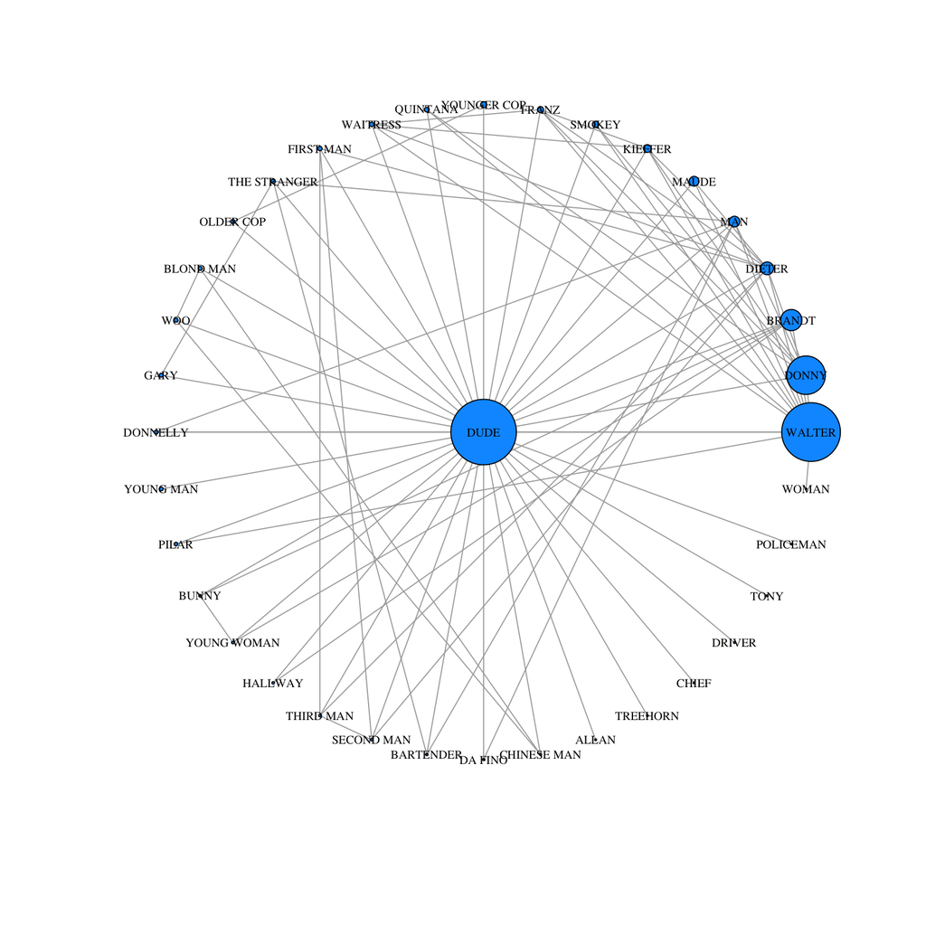

```r
plot(g,
     layout = layout.star(g, center = V(g)["DUDE"], order = order(df$eig, decreasing = TRUE)),
     vertex.size=df$eig*20,
     vertex.color="#009bff",
     vertex.label.cex=0.7,
     vertex.label.color="black",
     vertex.frame.color="black")
```